# Cross-lingual transfer analysis

Languages are ordered by resource level and coloured on a sequential ramp rather than with categorical hues: resource is a magnitude, so the colour should carry the ordering. The legend states each language’s absolute Common Crawl page count; the spread is large, from ~0.6M pages for Marathi to ~880M for English. `mako` runs dark to light through a single blue-green hue, is monotonic in lightness (so the order survives greyscale and colour-vision deficiency), and avoids the pale yellow end of `viridis` that disappears against a white panel. Highest-resource language is darkest.

```r
language_levels <- cells %>%
  distinct(language, log10_common_crawl_pages) %>%
  arrange(desc(log10_common_crawl_pages))

# Label with the resource value so the legend states the ordering explicitly.
# Label with the absolute Common Crawl page count, so the legend states the
# ordering in a concrete unit rather than a log value or a ratio to English.
pages_lab <- function(l) {
  v <- 10^l
  ifelse(v >= 1e9, paste0(round(v/1e9, 1), "B"), paste0(round(v/1e6), "M"))
}
language_labels <- sprintf("%s (%s)", language_levels$language,
                           pages_lab(language_levels$log10_common_crawl_pages))
names(language_labels) <- language_levels$language

language_levels
```

```
## # A tibble: 15 × 2
##    language log10_common_crawl_pages
##    <chr>                       <dbl>
##  1 eng                          8.95
##  2 rus                          8.14
##  3 deu                          8.11
##  4 jpn                          8.07
##  5 fra                          8.01
##  6 zho                          8.01
##  7 ita                          7.73
##  8 nld                          7.60
##  9 ukr                          7.24
## 10 ara                          7.15
## 11 dan                          7.06
## 12 hin                          6.68
## 13 est                          6.49
## 14 isl                          5.89
## 15 mar                          5.81
```

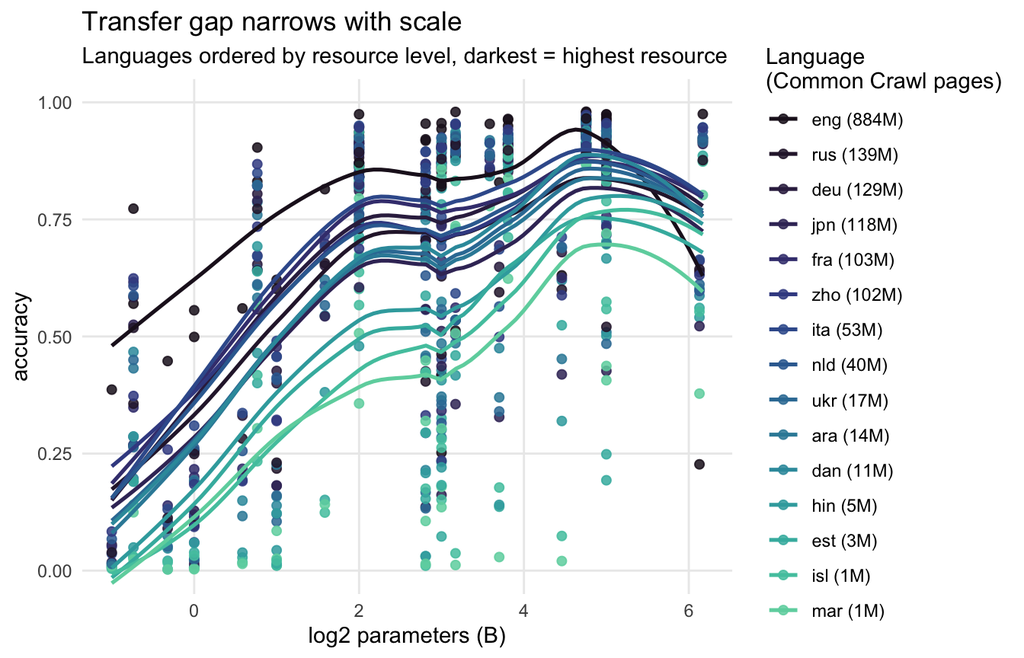

```r
cells %>%
  group_by(model, language, log2_params) %>%
  summarise(accuracy = sum(n_correct) / sum(n_total), .groups = "drop") %>%
  mutate(language = factor(language, levels = language_levels$language)) %>%
  ggplot(aes(log2_params, accuracy, colour = language)) +
  geom_point(alpha = 0.85, size = 1.8) +
  geom_smooth(se = FALSE, method = "loess", formula = y ~ x, linewidth = 0.9) +
  scale_colour_viridis_d(
    option = "mako", begin = 0.08, end = 0.82, direction = 1,
    labels = language_labels
  ) +
  # loess is unconstrained and overshoots 1.0 at the top end; clip the view
  # rather than the data so the smoother still sees every point.
  coord_cartesian(ylim = c(0, 1)) +
  labs(
    x = "log2 parameters (B)", y = "accuracy",
    colour = "Language\n(Common Crawl pages)",
    title = "Transfer gap narrows with scale",
    subtitle = "Languages ordered by resource level, darkest = highest resource"
  ) +
  theme_minimal() +
  theme(panel.grid.minor = element_blank())
```